# Data Analysis

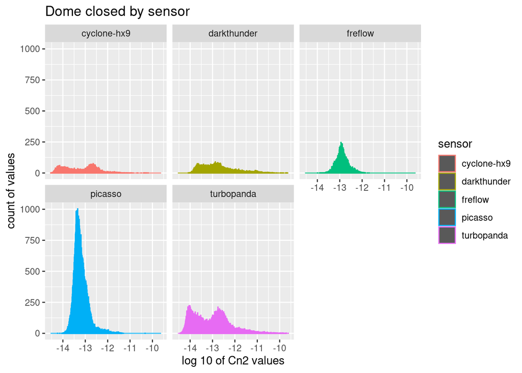

```r
# Show by sensor when dome is closed
sensorSlit %>% filter(slit=="-1") %>%
ggplot( aes(x=(log(Cn2, base = 10)), color=sensor)) +
  geom_histogram(bins=500) +
  facet_wrap(~sensor, scales="fixed") +
  labs(title="Dome closed by sensor", x= "log 10 of Cn2 values", y= "count of values")
```

1. What is the average daytime and nighttime (or maybe nighttime+dome open) Cn2 values per sensor? What are the corresponding standard deviations?

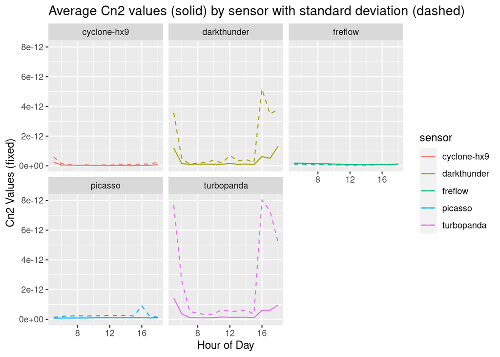

```r
#make the dataframe: average Cn2 values per sensor, split between day and night, by hour.

# Okay. The point here is to make the average values of the Cn2 values every hour.
# So we first group by the sensor. this means any like sum thing we do won't be all of them, but will isolate them based on sensor
# Then we create a new column with just the hour because we don't really care about the minutes of the night, and it was proving too difficult to do so.
# Then we once again group by sensor, but also by hourTime, so that
# we can then take the average Cn2 value, and it will give us the average cn2 value at that time of night from that sensor.

day_avg_byHour <- sensorMaster %>% group_by(sensor) %>%
                            mutate(hourTime= hour(dateTime)) %>%
                            filter(hourTime >= 5 & hourTime <= 18) %>%
                            group_by(sensor, hourTime) %>%
                            mutate(std_dev =sd(Cn2)) %>%
                            group_by(sensor, hourTime, std_dev) %>%
                            summarize(hourAvg= mean(Cn2))

#plot
day_avg_byHour_plot <- day_avg_byHour %>% ggplot(aes(x=hourTime, color=sensor)) +
                            geom_line(aes(y=hourAvg )) +
                            geom_line(aes(y=std_dev), linetype="dashed") +
                            facet_wrap(~sensor, scales="fixed")+
                            labs(title="Average Cn2 values (solid) by sensor with standard deviation (dashed)",
                                 x= "Hour of Day", y= "Cn2 Values (fixed)")
#display
day_avg_byHour_plot
```

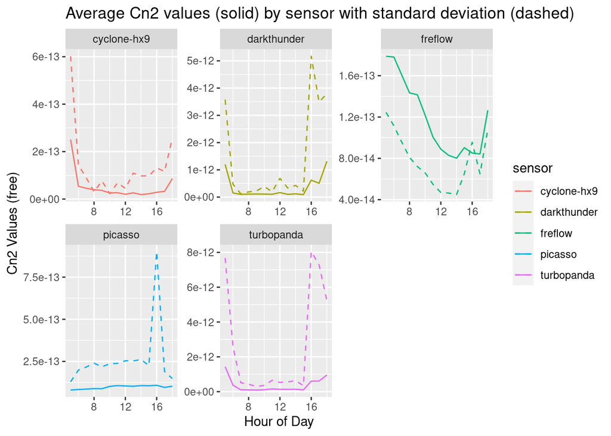

```r
day_avg_byHour_plot <- day_avg_byHour %>% ggplot(aes(x=hourTime, color=sensor)) +
                            geom_line(aes(y=hourAvg )) +
                            geom_line(aes(y=std_dev), linetype="dashed") +
                            facet_wrap(~sensor, scales="free")+
                            labs(title="Average Cn2 values (solid) by sensor with standard deviation (dashed)",
                                 x= "Hour of Day", y= "Cn2 Values (free)")
#display
day_avg_byHour_plot
```

I note that everything so far has been seemingly ignoring the time discrepancies between all the sensors.

Further Questions to explore:

Do these values change if you cut your sample size in half (first half and second half or odd samples v. even samples)?  
For nighttime dome open measurements (and maybe separately for closed dome measurements)

1. do the sensor values show any dependence on difference in temperature between the
   1. mirror and the tube, or the b) mirror and the outside air, or the c) tube and the outside air?
2. versus time of day, and
3. versus the direction of the dome with respect to the wind direction reported by the CFHT/Gemini weather tower?